# AN 588 Week 3

Erin Anderson

2023-10-01

## Challenges

What you learned from running their Original Homework Code that helped improve your own code.

What you did in your own code that might help to improve theirs.

What challenges, if any, you both faced in your code that could not be helped by comparison.

Whether the annotation/commenting on your peer’s Original Homework Code is readable and interpretable to you, and if not then how it could be improved.

## What is the probability she will hear more than 8 calls during any given session?

```r
eight_calls <- ppois(q = 8, lambda = 15, upper.tri(TRUE))
eight_calls
```

```
## [1] 0.9625535
```

## Probability of no calls

```r
no_calls <- dpois(x = 0, lambda =15)
no_calls
```

```
## [1] 3.059023e-07
```

## Probability of exactly 3 calls

```r
three_calls <- dpois(x = 3, lambda =15)
three_calls
```

```
## [1] 0.0001720701
```

## Plot the relevant Poisson mass function over the values in range 0 ≤ x ≤ 30.

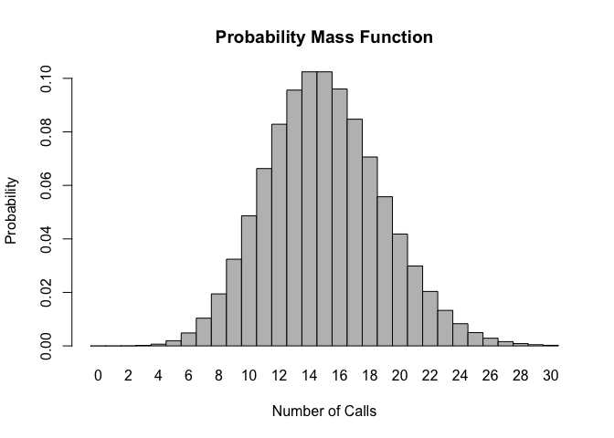

```r
x <- 0:30
l = 15
probset <- dpois(x = x, lambda = l)
barplot(probset, names.arg = x, space = 0, xlab = "Number of Calls", ylab = "Probability", main = "Probability Mass Function")
```

## Simulate 104 results from this distribution (i.e., 2 years of Saturday monitoring sessions)

```r
two_years <- rpois(104, lambda =15)
two_years
```

```
##   [1] 18 12 21 11 13 17 21 17 22 19 15 17 21 18 12 13 10 17 16 15 11 15 23 11 20
##  [26] 16 15 16 14 13 15 11 14 14 20 16 19 17 19 11 20 12 19 14 11 19 13 15 13 15
##  [51] 11 14 14 17 18 15 11 19 14 15 10 11 16 11 14 18 15 14 11 12 13 10 12 18 16
##  [76]  9 14 20 11 15 11  9 14  9 19 13 10 10 13 14 11 13 12 20 19 14 16 13 12 12
## [101] 17 11 13 22
```

## Plot the simulated results using hist() and use xlim() to set the horizontal limits to be from 0 to 30

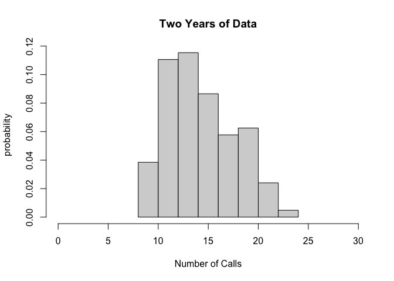

```r
hist(two_years, probability = TRUE, main = "Two Years of Data",
    xlab = "Number of Calls", ylab = "probability", xlim = c(0,30))
```

The rest of the HW 2 problems look good. We used the same functions, so I don’t really have any other suggestions about your code other than the few I left. One suggestion I have is to leave comments about the functions you’re using and what they do - sort of like a step-by-step. Sofi actually suggested this to me for HW 1. It’s a great strategy for replicating your work in the future or just to follow your train of thought. If you leave detailed comments about your code, it’s easier to return to it, pick up where you left off, and understand what you were doing. Even though I understood your code, other readers (theoretically) might not understand what all of the functions do, and it might be helpful to leave a step-by-step. I did this in mine if you want to take a look. Overall, though, great work here Erin! :) - Julianna